# Precipitation manipulation experiments – diagnostics and illustrations

**This document is for CostaRica**

The schedule for the precipitation experiment is based on rainfall data for our local sites. This document will illustrate the process of calculating schedules from rainfall data. A modified version of this document could be a useful supplementary material for our eventual papers. In the meantime it will help us understand how the code works in the first place.

```r
## site = the name of the folder in which the data is stored (not the
## directory, as the code will figure that out.  Times = the number of
## permutations of rainfall days to be simulated.  The 'best' pemutation
## is selected from among them.

## build path name
datapath <- file.path("~/Dropbox/PhD/precipitation/Experimental.Schedules/",
    site)

## you have to have the data in there first
if (file.exists(datapath) == FALSE) stop("There is no folder with that name!")

fieldsite.dir <- datapath

## get all the .csv files from that directory, and check that one starts
## with 'Ppt'
csvs <- list.files(pattern = "*.csv", path = fieldsite.dir)
rainfall.file <- pmatch("Ppt", csvs, nomatch = NA)
if (length(rainfall.file) != 1) stop("make sure there is one and only one file with 'Ppt' in the name")
ppt.file <- file.path(fieldsite.dir, csvs[rainfall.file])

## read in the data
rainfall.data <- read.csv(file = ppt.file)

## add a stop line if less than 60!  or just a message li

if (nrow(rainfall.data) != 60) stop("wrong number of rows in the input data!")

## estimate parameters for the negative binomial distribution for each
## year **independently**, then take the mean of all these.
yearly.params <- sapply(rainfall.data[1:60, ], nbin.estimate)
params.rainfall <- rowMeans(yearly.params)
```

```r
make.points <- function(one.year.data) {
    freqs <- as.numeric(table(one.year.data))
    rainfalls <- sort(unique(one.year.data))
    data.frame(amount = rainfalls, frequency = freqs)
    # one.yr.data <- data.frame(rainfalls=rainfalls,freqs=as.numeric(freqs))
    # one.yr.data <- one.yr.data[order(one.yr.data$rainfalls),]
    # with(one.yr.data,lines(rainfalls,freqs))
}
```

## Fitting the Negative Binomial distribution to raw rainfall data

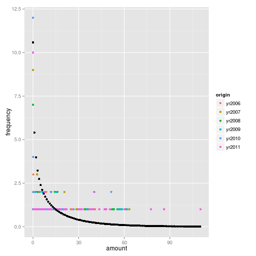

```r
## use these average parameter estimates to calculate the 'new data',
## derived from the probability density function
new.data <- integerized(mean.dist = params.rainfall["mu"], k = params.rainfall["k"])

rainfall.probs <- sapply(0:max(rainfall.data), dnbinom, mu = params.rainfall["mu"],
    size = params.rainfall["k"])

rainfall.pred.model <- rbind(data.frame(origin = "model", amount = 0:max(rainfall.data),
    frequency = rainfall.probs * 60), data.frame(origin = "newdata", make.points(new.data)))

rainfall.points.list <- lapply(rainfall.data, make.points)
yearnames <- rep(names(rainfall.points.list), sapply(rainfall.points.list, nrow))

rainfall.pred.model <- rbind(rainfall.pred.model, data.frame(origin = yearnames,
    do.call(rbind, rainfall.points.list)))

ggplot(subset(rainfall.pred.model, subset = !rainfall.pred.model$origin %in%
    c("model", "newdata")), aes(x = amount, y = frequency, colour = origin)) +
    geom_point() + geom_point(data = subset(rainfall.pred.model, subset = rainfall.pred.model$origin ==
    "model"), colour = "black", size = 2)
```

This graph shows the frequency distribution of rainfall amounts for all the years in the data you submitted. Rainfall amount is on the x-axis (in millimeters) and the number of days is on the y-axis.

We fit a Negative Binomial distribution to this data. This is a several-step process:

1. Round rainfall amounts to integers
2. Estimate *mu* and *k* for each year of the dataset using maximum likelihood
3. average these parameters to produce the “average distribution”

This average distribution is shown in black against all the raw data, which is shown in colour. You can see that it fits rather well – except for the long tail, which predicts <1 day for many of the large rainfall amounts.

## “integerizing” the distribution.

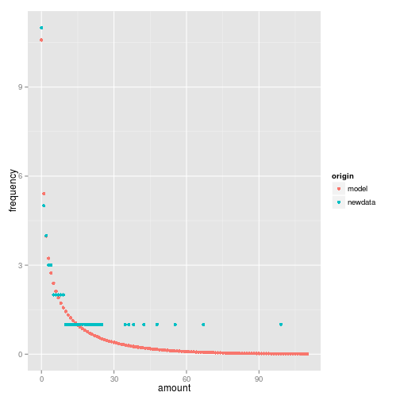

```r
ggplot(subset(rainfall.pred.model, subset = rainfall.pred.model$origin %in%
    c("model", "newdata")), aes(x = amount, y = frequency, colour = origin)) +
    geom_point()
```

This figure shows the negative binomial prediction (as above). However, it cannot be used directly because it predicts non-integer frequencies for each rainfall amount (and of course we cannot water for a non-integer number of days!). We came up with an 'integerization' algorithim which approximates this smooth line with the discrete points shown here. The algorithim works like this: when we round the non-integer frequencies of rainfall amounts to round numbers, we either increase or decrease by a small amount (<1). We add together the “leftovers”, until we get a quantity equal to one. We multiply each “leftover” by its rainfall amount, and add them together.

The above figure shows that the resulting integers are OK (not perfect) at fitting the nice, smooth negative binomial line.

## altering the parameters – applying the experimental treatment

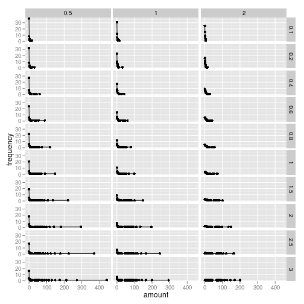

```r
## first make the vector of shifts then multiply them!  makes all the
## steps easier
mu.shift <- c(0.1, 0.2, 0.4, 0.6, 0.8, 1, 1.5, 2, 2.5, 3)
k.shift <- c(0.5, 1, 2)
param.space <- expand.grid(mu = mu.shift, k = k.shift)
trt.name <- apply(param.space, 1, function(param.vec) {
    param.vec <- param.vec
    paste("mu", param.vec["mu"], "k", param.vec["k"], sep = "")
})
param.space["mu"] <- param.space["mu"] * params.rainfall["mu"]
param.space["k"] <- param.space["k"] * params.rainfall["k"]

param.space.list <- split(param.space, list(1:nrow(param.space)))

treatments <- lapply(param.space.list, FUN = function(param.vec) integerized(mean.dist = param.vec[["mu"]],
    k = param.vec[["k"]]))

## some of these are too long!  it seems to be the result of a weird quirk
## in the rounding when there is very high mu and very small k the error
## adds a single extra zero.  this little bit of code here deletes the
## last zero in all vectors which are 'too long'.
too.long <- which(sapply(treatments, length) > 60)
for (k in too.long) {
    zero <- max(which(treatments[[k]] == 0))
    treatments[[k]] <- treatments[[k]][-zero]
}


trt.list.freqs <- lapply(treatments, make.points)
n.rainy.days <- sapply(trt.list.freqs, nrow)

param.space.label <- expand.grid(mu = as.character(mu.shift), k = as.character(k.shift))

trt.rainfalls <- data.frame(mu = rep(param.space.label[["mu"]], n.rainy.days),
    k = rep(param.space.label[["k"]], n.rainy.days), trt.name = rep(trt.name,
        n.rainy.days), do.call(rbind, trt.list.freqs))

ggplot(trt.rainfalls, aes(x = amount, y = frequency, group = trt.name)) + geom_point() +
    geom_path() + facet_grid(mu ~ k)
```

Each panel represents the distribution of days within one treatment (bromeliad). Rows are variation in the *mu* parameter, while columns are *k*. These are the treatments which we decided on as a group: increases & decreases in the two parameters of the distribution.

## patterning the rainfall appropriately

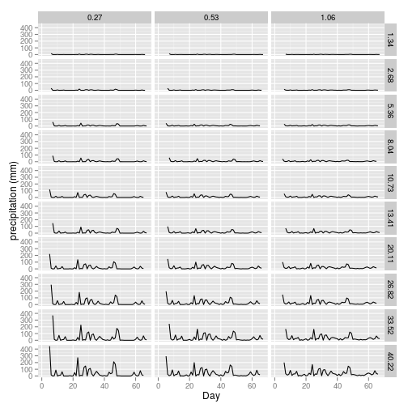

```r
schedname <- paste(datapath, "/", site, "schedule.csv", sep = "")
if (!exists(schedname)) {
    schedname <- list.files(pattern = "chedule.csv", full.names = TRUE)
}
schedule <- read.csv(schedname, na.strings = c("NA", "sample", "insects"), stringsAsFactors = FALSE)
melted.schedule <- melt(data = schedule, id.vars = names(schedule)[1:4])

melted.schedule$Day <- as.numeric(gsub(melted.schedule$variable, pattern = "[a-zA-Z]+",
    replacement = ""))

ggplot(melted.schedule) + facet_grid(intended.mu ~ intended.k) + geom_path(aes(x = Day,
    y = value)) + ylab("precipitation (mm)")
```

The temporal pattern of rain in each bromeliad – equal to the previous figure but with the addition of a sequence of rainfall that approximates the variation natural to the site.

## Temporal patterns determined in this way are indistinguishable from nature

We were very concerned, at the beginning of the experiment, to create a sequence of rainfall events which resembled each site's natural pattern. In this section, the actual rainfall data is compared to the 'control' treatment (mu1k1), in which the parameters are equal to the average of their annual values from the observed data. Hopefully, you can see no differences between this treatment and the others.

```r
raw.schedules <- data.frame(day = rep(1:60, times = ncol(rainfall.data)), melt(rainfall.data))
```

```
## Using as id variables
```

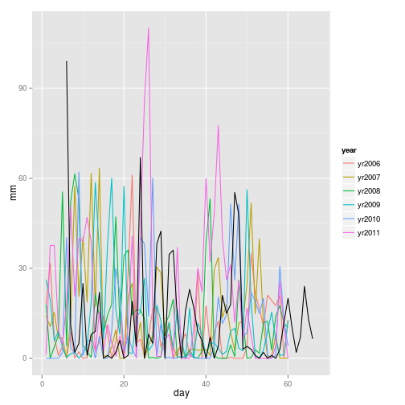

```r
names(raw.schedules) <- c("day", "year", "mm")

control.only <- melted.schedule[melted.schedule$trt.name == "mu1k1", c("Day",
    "trt.name", "value")]
names(control.only) <- c("day", "year", "mm")

also.control <- rbind(control.only, raw.schedules)

ggplot(data = subset(also.control, also.control$year != "mu1k1"), aes(x = day,
    y = mm, colour = year)) + geom_path() + geom_path(data = subset(also.control,
    also.control$year == "mu1k1"), colour = "black")
```

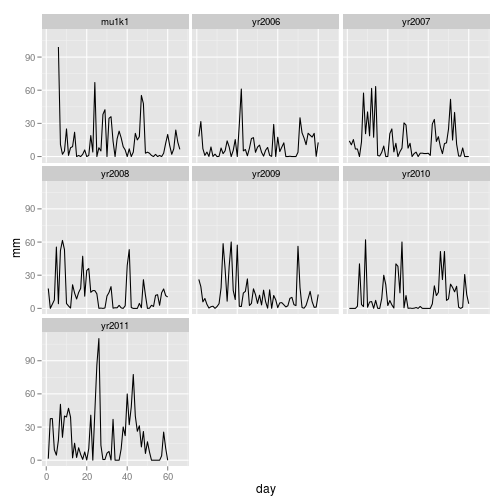

```r
ggplot(data = also.control, aes(x = day, y = mm)) + geom_path() + facet_wrap(~year)
```